# Asking the right questions

Etienne Beaulac

1/17/2018

## Has the rate of cancer among Americans increased over the past century?

> “I really like it because it is a problem that we are facing in our society and I feel like the media has inflated it a lot. So it would be interesting to know if it is getting worse, or if it is simply its diagnosis that has made it appear more apparent.”

> “That is an interesting question. I would say the hardest part would be getting quality health care data to look into it.”

> “I’d say the question is of definite importantance, but accurate studies could be hard to find, and new studies may need to be done”

> “This one is interesting to think about, but it would mostly be analysing data, and maybe not too interesting. The answer might even already exist.”

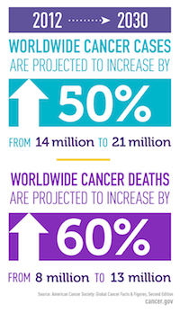

[Cancer Statistics](https://www.cancer.gov/about-cancer/understanding/statistics)

## What are the most successful fast food products available?

### Rework of question: What are the most popular fast food chains available?

### Rework of question: What item on the [insert food chain here] menu makes the most money & how does it compare to the advertisement

> “I think that this is a very interesting question, especially in a society like ours where we consume fast food a lot. As an individual I feel like I have some ideas of what these foods might be but I bet that data can help us all to see if our assumptions are true.”

> “I think it could be interesting, but in my opinion it’s a little vague. Like, what makes the product successful? How would you use the findings? (maybe this second one is going farther than the question requires.)”

> “Clarification: accurate historical studies could be hard to find. An unexpected but interesting question. The issue of availability vs target area comes to mind. Successful where specifically, and what competition is available in said area? Not much of a question if the target area is limited to a handful of fast food joints without much competition.”

> “Maybe use just one chain, compare the popularity to the advertisement. Also interesting to see how the chains rank against each other, especially for the less popular ones.”

[Top 20 Fast Food restaurants](http://www.businessinsider.com/the-20-most-successful-fast-food-chains-in-america-2015-8/#20-papa-johns-1)

This is a difficult article to read because the pictures are so big. A nice graph or simple visual would make this article much easier and more pleasing.

## At which rate are people coming up with new words that are being added to dictionaries?

> “Having seen the rise of ‘selfie’, I think that it is a very interesting question. I think that in a world of globalization and popular social media people are coming up with their own words all the time. I’m curious to see at what rate they are doing so.”

> “That is a super cool question. I like it. Getting data might be difficult, but that could be a fun one to explore. Especially if you could get older data - say before the internet - and see how fast the information age has changed the spread of new words and ideas. Difficult to analyze, but a really cool question in my opininon.”

> “I really like this question, it could be expanded into a whole area of topics like how fast are different languages expanding, and how many words from different languages are being added to a given one (e.g. English words being added officially into Italian), how long does it take for a new word to become official, and many more.”

> “I really like that one, a lot. It’s not something you think about everyday. It’s kinda like Google analytics for the words, but it would be more comprehensive. It would be cool to look at multiple dictionaries and see how much they have each changed over the years. It would also be interesting to see if newer words are more specific vs older words.”

All I could find was the statistics from Google showing the usage for the certain words.

## Is it statistically better to get a job or “do your own thing” for 40 years?

### Rework of question: Is it more lucrative to get a stable job or “do your own thing” (including investments and other) for 40 years?

> “That’s a great question. As a student looking forward to graduation and starting a job this is something that has corssed my mind a lot. I can ask different people and they will give me their opinions but I am excited to see what data truly has to say.”

> “This last question is definitely too vague. Maybe focus on a specific industry like, “is it more lucrative to get a job as a web developer right out of college or try to free-lance.””

> “Good question but needs clarification is necessary, what exactly entitles”doing your own thing“, are we talking entrepreneurship, or just doing oddjobs, both, or something else entirely? And statistically better how? Monetarily? Emotionally?”

> “Financially, I feel like it would be interesting, but having a job would be more stable compared to ‘doing your own thing’, and that would make the data possibly skewed.”